# NHANES Data Presentation

Haley Grant, Runzhe Li, Zebin Wang

October 23, 2019

```r
library(rnhanesdata)
library(ggplot2)
library(ggpubr)
library(dplyr)
library(tidyr)
library(tidyverse)
library(magrittr)
library(data.table)
library(mgcv)
library(refund)
library(gridExtra)

data("PAXINTEN_C");data("PAXINTEN_D")    ## activity count data matrices
data("Flags_C");data("Flags_D")          ## wear/non-wear flag data matrices
data("Covariate_C");data("Covariate_D")  ## demographic/comorbidity data matrices
```

### Data Reliability

PAXCAL and PAXSTAT are columns that show data reliability for each row. PAXCAL denotes the calibration of the device (1 if calibrated, 2 if not, and 9 if unknown). PAXSTAT denotes the data reliability status (1 if reliable, 2 if not).

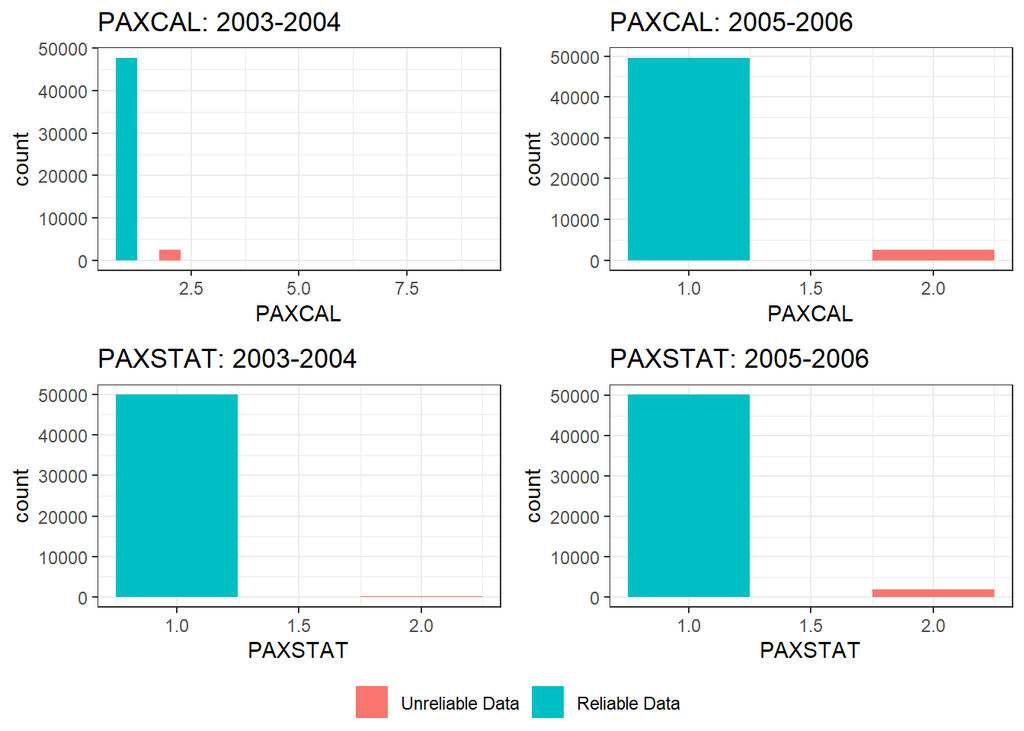

```r
#colnames(PAXINTEN_C)

# View number of inadequate rows
ggc1 = ggplot(data = PAXINTEN_C, aes(x = PAXCAL))+geom_bar(aes(fill = PAXCAL==1),position = position_dodge(width = 0.8), width=0.5)+
  labs(title = "PAXCAL: 2003-2004")+
  scale_fill_discrete(name = NULL,labels = c("Unreliable Data","Reliable Data"))+
  theme_bw()
ggc2 = ggplot(data = PAXINTEN_C, aes(x = PAXSTAT))+geom_bar(aes(fill = PAXSTAT==1),position = position_dodge(width = 0.8), width=0.5)+
  labs(title = "PAXSTAT: 2003-2004")+
  scale_fill_discrete(name = NULL,labels = c("Unreliable Data","Reliable Data"))+
  theme_bw()
ggd1 = ggplot(data = PAXINTEN_D, aes(x = PAXCAL))+geom_bar(aes(fill = PAXCAL==1),position = position_dodge(width = 0.8), width=0.5)+
  labs(title = "PAXCAL: 2005-2006")+
  scale_fill_discrete(name = NULL,labels = c("Unreliable Data","Reliable Data"))+
  theme_bw()
ggd2 = ggplot(data = PAXINTEN_D, aes(x = PAXSTAT))+geom_bar(aes(fill = PAXSTAT==1),position = position_dodge(width = 0.8), width=0.5)+
  labs(title = "PAXSTAT: 2005-2006")+
  scale_fill_discrete(name = NULL, labels = c("Unreliable Data","Reliable Data"))+
  theme_bw()

ggarrange(ggc1,ggd1,ggc2,ggd2 ,ncol = 2, nrow = 2, common.legend = T, legend = "bottom")
```

### Average activity counts over time

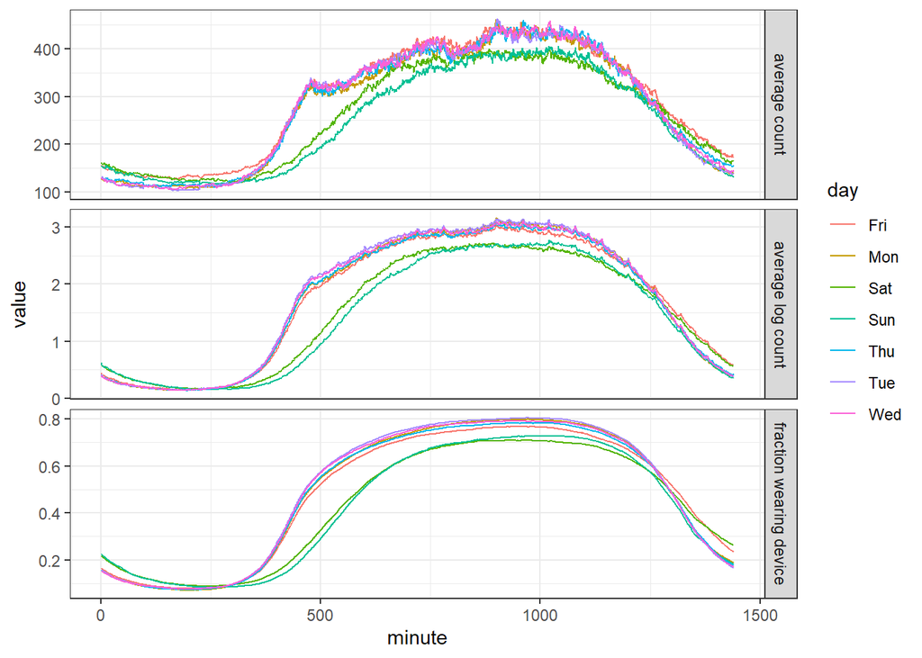

```r
PAXINTEN     <- bind_rows(PAXINTEN_C, PAXINTEN_D)
PAXINTEN_log <- bind_cols(PAXINTEN[, 1:5], log(PAXINTEN[, -c(1:5)] + 1))
Flags        <- bind_rows(Flags_C, Flags_D)

mean_column <- function(col_name, data) {
    sapply(1:7, function(i) {
        tmp <- data %>%
            filter(WEEKDAY == i) %>%
            select(starts_with("MIN"))
        colMeans(tmp, na.rm = TRUE)
    }) %>%
        set_colnames(c("Sun", "Mon", "Tue", "Wed", "Thu", "Fri", "Sat")) %>%
        as_tibble() %>%
        mutate(minute = 1:n()) %>%
        gather(key = "day", value = "value", -minute)
}

bind_rows(
    mean_column(col_name = "count", data = PAXINTEN)     %>% mutate(key = "count"),
    mean_column(col_name = "log"  , data = PAXINTEN_log) %>% mutate(key = "log"),
    mean_column(col_name = "flag" , data = Flags)        %>% mutate(key = "flag")
) %>%
    mutate(key = factor(key,
                        levels = c("count", "log", "flag"),
                        labels = c("average count",
                                   "average log count",
                                   "fraction wearing device"))) %>%
    ggplot(aes(x = minute, y = value, colour = day)) +
    geom_line() +
    facet_grid(key ~ ., scales = "free_y") +
    theme_bw()
```

### Removing non-wear timepoints

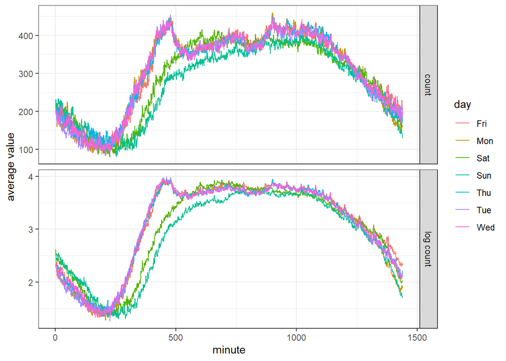

```r
PAX       <- bind_rows(PAXINTEN_C, PAXINTEN_D) %>% filter(PAXCAL==1 & PAXSTAT==1)
Flags_mat <- bind_rows(Flags_C, Flags_D) %>% filter(PAXCAL==1 & PAXSTAT==1)
PAX_front <- PAX[, 1:5]
PAX_back  <- PAX[, -c(1:5)]
rm(PAX)

Flags_mat <- Flags_mat[, -c(1:5)]
PAX_back[Flags_mat==0] <- NA
rm(Flags_mat)

PAX_clean <- bind_cols(PAX_front, PAX_back)
rm(PAX_front, PAX_back)

PAX_clean_log <- bind_cols(PAX_clean[, 1:5], log(PAX_clean[, -c(1:5)] + 1))


bind_rows(
    mean_column(col_name = "count", data = PAX_clean)     %>% mutate(key = "count"),
    mean_column(col_name = "log"  , data = PAX_clean_log) %>% mutate(key = "log count")
) %>%
    ggplot(aes(x = minute, y = value, color = day)) +
    geom_line() +
    facet_grid(key ~ ., scales = "free_y") +
    theme_bw() +
    labs(y = "average value")
```

```r
sum(PAXINTEN_C$PAXCAL != Flags_C$PAXCAL)
```

```
## [1] 0
```

```r
sum(PAXINTEN_C$PAXSTAT != Flags_C$PAXSTAT)
```

```
## [1] 0
```

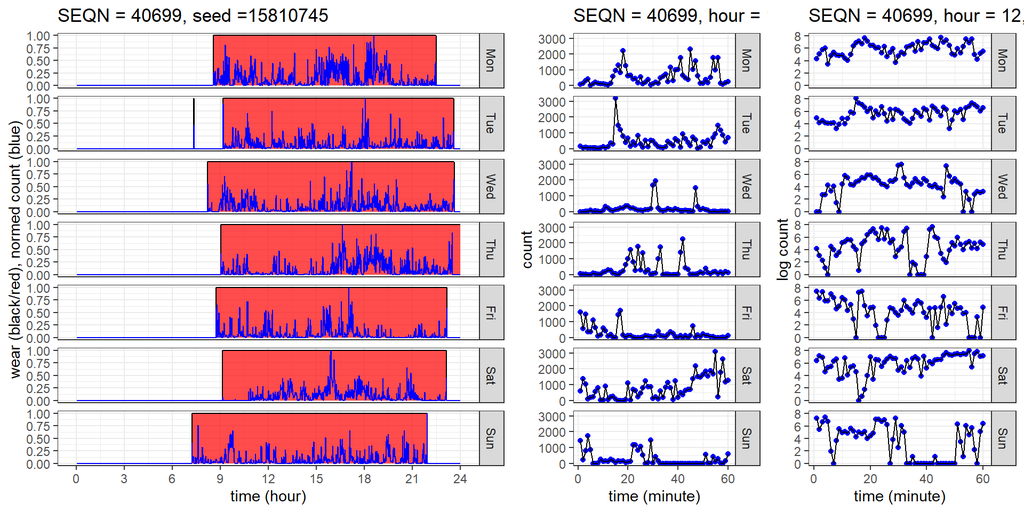

```r
wear <- bind_rows(Flags_C, Flags_D) %>%
    filter(PAXCAL==1 & PAXSTAT==1) %>%
    select(-c(PAXCAL, PAXSTAT)) %>%
    mutate(WEEKDAY = factor(WEEKDAY,
                            levels = c(2:7, 1),
                            labels = c("Mon", "Tue", "Wed", "Thu", "Fri",
                                       "Sat", "Sun")))
count <- bind_rows(PAXINTEN_C, PAXINTEN_D) %>%
    filter(PAXCAL==1 & PAXSTAT==1) %>%
    select(-c(PAXCAL, PAXSTAT)) %>%
    mutate(WEEKDAY = factor(WEEKDAY,
                            levels = c(2:7, 1),
                            labels = c("Mon", "Tue", "Wed", "Thu", "Fri",
                                       "Sat", "Sun")))

px_wear <- function(w = wear, id) {
    w %>%
        filter(SEQN==id) %>%
        gather(key = minute, value = wear, -c(SEQN, WEEKDAY, SDDSRVYR)) %>%
        mutate(minute = substr(minute, 4, nchar(minute)),
               minute = as.integer(minute))
}

px_count <- function(c = count, id) {
    c %>%
        filter(SEQN==id) %>%
        gather(key = minute, value = count, -c(SEQN, WEEKDAY, SDDSRVYR)) %>%
        mutate(minute = substr(minute, 4, nchar(minute)),
               minute = as.integer(minute)) %>%
        group_by(WEEKDAY) %>%
        mutate(maxdaycount = max(count)) %>%
        ungroup()
}

plot_day <- function(w = wear,
                     c = count,
                     id = NULL,
                     seed = NULL) {

    if (is.null(id)) {
        ids <- unique(w$SEQN)
        if (is.null(seed)) { seed <- sample(.Machine$integer.max, 1) }
        set.seed(seed)
        id <- sample(ids, 1)
    }

    wear <- px_wear(w = w, id = id)
    count <- px_count(c = c, id = id)

    wear %>%
        ggplot(aes(x = minute*24/1440, y = wear)) +
        geom_area(fill = "red", alpha = .7) +
        geom_line() +
        facet_grid(WEEKDAY ~ .) +
        scale_x_continuous(breaks = seq(0, 24, 3)) +
        labs(x = "time (hour)",
             y = "wear (black/red), normed count (blue)",
             title = paste0("SEQN = ", id, ", seed =", seed)) +
        theme_bw() +
        geom_line(data = count,
                  aes(x = minute*24/1440, y = count/maxdaycount),
                  color = "blue")
}

plot_hour <- function(w = wear,
                      c = count,
                      id,
                      h) {

    wear <- px_wear(w = w, id = id)
    count <- px_count(c = c, id = id) %>%
        select(-maxdaycount) %>%
        left_join(wear %>% select(WEEKDAY, SDDSRVYR, minute, wear),
                  by = c("WEEKDAY", "SDDSRVYR", "minute")) %>%
        mutate(count = ifelse(wear==1, count, NA)) %>%
        select(-wear) %>%
        filter(floor(minute*24/1440) == h) %>%
        mutate(minute = 1 + minute - min(minute))

    p1 <- count %>%
        ggplot(aes(x = minute, y = count)) +
        geom_point(color = "blue") +
        geom_line() +
        facet_grid(WEEKDAY ~ .) +
        labs(x = "time (minute)",
             y = "count",
             title = paste0("SEQN = ", id, ", hour = ", h, ", scale = raw")) +
        theme_bw()

    p2 <- count %>%
        ggplot(aes(x = minute, y = log(count + 1))) +
        geom_point(color = "blue") +
        geom_line() +
        facet_grid(WEEKDAY ~ .) +
        labs(x = "time (minute)",
             y = "log count",
             title = paste0("SEQN = ", id, ", hour = ", h, ", scale = log")) +
        theme_bw()

    gridExtra::grid.arrange(p1, p2, ncol = 2)

}


gridExtra::grid.arrange(
    plot_day(seed = 15810745),
    plot_hour(id = 40699, h = 12),
    ncol = 2
)
```

### Drinking Status

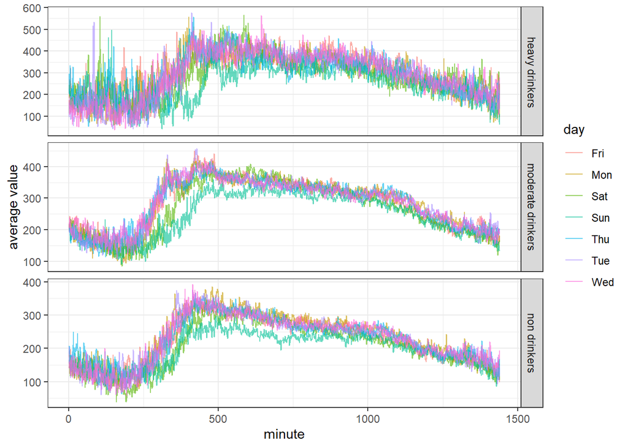

```r
demog = bind_rows(Covariate_C,Covariate_D)%>% filter()

pat.id.del = unique(c(PAXINTEN_C$SEQN[PAXINTEN_C$PAXCAL!=1], PAXINTEN_C$SEQN[PAXINTEN_C$PAXSTAT!=1], PAXINTEN_D$SEQN[PAXINTEN_C$PAXCAL!=1],PAXINTEN_D$SEQN[PAXINTEN_C$PAXSTAT!=1]))

demog = filter(demog, !(SEQN %in% pat.id.del))

hv.drnk = demog$SEQN[which(demog$DrinkStatus=="Heavy Drinker")]
mod.drnk = demog$SEQN[which(demog$DrinkStatus=="Moderate Drinker")]
non.drnk = demog$SEQN[which(demog$DrinkStatus=="Non-Drinker")]

children = demog$SEQN[which(demog$RIDAGEYR<18)]
adult = demog$SEQN[which(demog$RIDAGEYR %in% c(18:65))]
retired = demog$SEQN[which(demog$RIDAGEYR>65)]

bind_rows(
    mean_column(col_name = "count", data = PAX_clean%>% filter(SEQN %in% non.drnk))%>% mutate(key = "non drinkers"),
     mean_column(col_name = "count", data = PAX_clean%>% filter(SEQN %in% mod.drnk))%>% mutate(key = "moderate drinkers"),
    mean_column(col_name = "count", data = PAX_clean%>% filter(SEQN %in% hv.drnk))%>% mutate(key = " heavy drinkers")
) %>%
    ggplot(aes(x = minute, y = value, color = day)) +
    geom_line(alpha = 0.6) +
    facet_grid(key ~ ., scales = "free_y") +
    theme_bw() +
    labs(y = "average value")
```

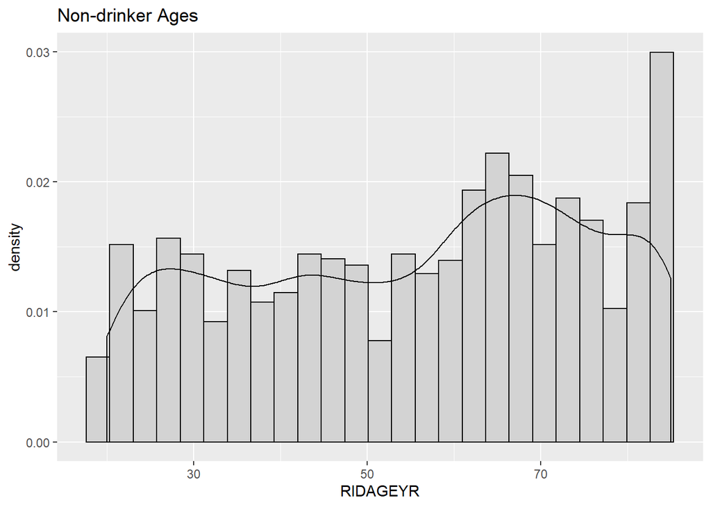

```r
demog%>% filter(DrinkStatus == "Non-Drinker") %>%
  ggplot(aes(x = RIDAGEYR, stat(density)))+geom_histogram(bins = 25, color = "black", fill = "lightgrey")+
  geom_density()+
  labs(title = "Non-drinker Ages")
```

```r
summary(demog%>% filter(DrinkStatus == "Non-Drinker") %>%
  select(RIDAGEYR))
```

```
##     RIDAGEYR
##  Min.   :20.00
##  1st Qu.:38.25
##  Median :59.00
##  Mean   :55.43
##  3rd Qu.:72.00
##  Max.   :85.00
```

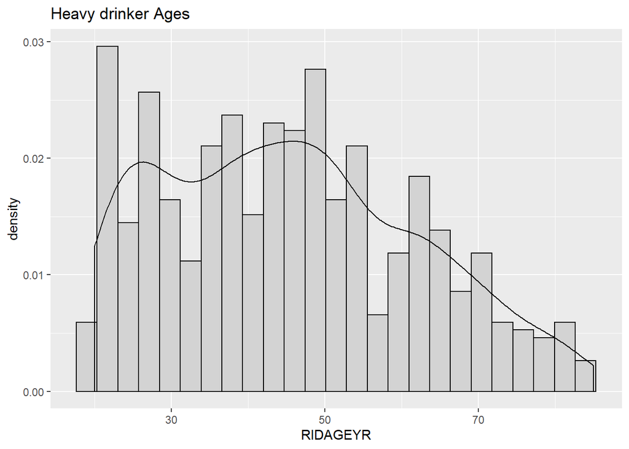

```r
demog%>% filter(DrinkStatus == "Heavy Drinker") %>%
  select(RIDAGEYR)%>%
  ggplot(aes(x = RIDAGEYR, stat(density)))+geom_histogram(bins = 25, color = "black", fill = "lightgrey")+
  geom_density()+
  labs(title = "Heavy drinker Ages")
```

```r
summary(demog%>% filter(DrinkStatus == "Heavy Drinker") %>%
  select(RIDAGEYR))
```

```
##     RIDAGEYR
##  Min.   :20.00
##  1st Qu.:32.00
##  Median :44.00
##  Mean   :45.25
##  3rd Qu.:57.00
##  Max.   :85.00
```

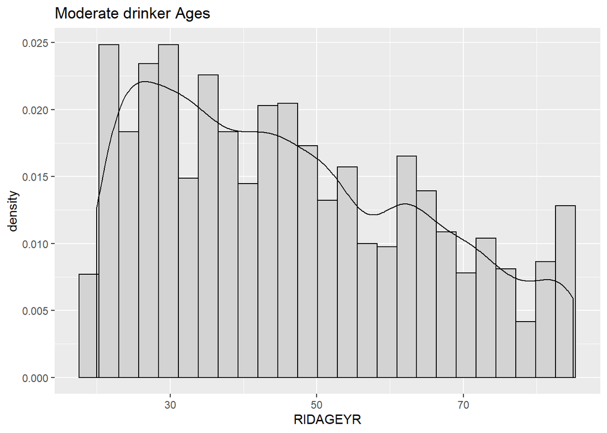

```r
demog%>% filter(DrinkStatus == "Moderate Drinker") %>%
  select(RIDAGEYR)%>%
  ggplot(aes(x = RIDAGEYR, stat(density)))+geom_histogram(bins = 25, color = "black", fill = "lightgrey")+
  geom_density()+
  labs(title = "Moderate drinker Ages")
```

```r
summary(demog%>% filter(DrinkStatus == "Moderate Drinker") %>%
  select(RIDAGEYR))
```

```
##     RIDAGEYR
##  Min.   :20.00
##  1st Qu.:31.00
##  Median :44.00
##  Mean   :46.34
##  3rd Qu.:61.00
##  Max.   :85.00
```

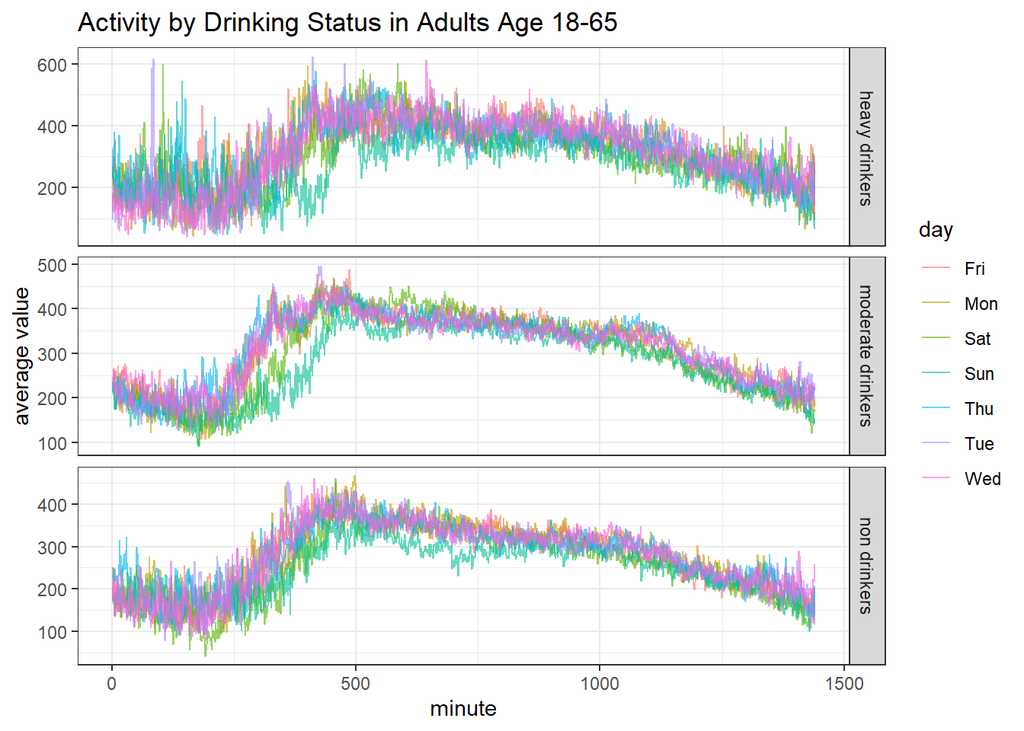

```r
bind_rows(
    mean_column(col_name = "count", data = PAX_clean%>% filter(SEQN %in% intersect(non.drnk, adult) ))%>% mutate(key = "non drinkers"),
     mean_column(col_name = "count", data = PAX_clean%>% filter(SEQN %in% intersect(mod.drnk, adult)))%>% mutate(key = "moderate drinkers"),
    mean_column(col_name = "count", data = PAX_clean%>% filter(SEQN %in% intersect(hv.drnk, adult)))%>% mutate(key = " heavy drinkers")
) %>%
    ggplot(aes(x = minute, y = value, color = day)) +
    geom_line(alpha = 0.6) +
    facet_grid(key ~ ., scales = "free_y") +
    theme_bw() +
    labs(y = "average value", title = "Activity by Drinking Status in Adults Age 18-65")
```

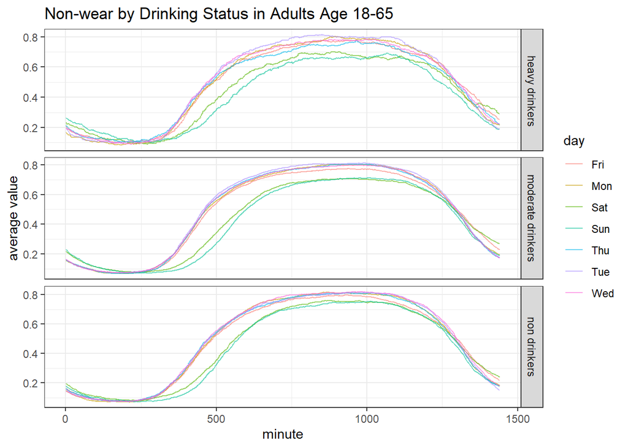

```r
bind_rows(
    mean_column(col_name = "count", data = Flags%>% filter(SEQN %in% intersect(non.drnk, adult) ))%>% mutate(key = "non drinkers"),
     mean_column(col_name = "count", data = Flags%>% filter(SEQN %in% intersect(mod.drnk, adult)))%>% mutate(key = "moderate drinkers"),
    mean_column(col_name = "count", data = Flags%>% filter(SEQN %in% intersect(hv.drnk, adult)))%>% mutate(key = " heavy drinkers")
) %>%
    ggplot(aes(x = minute, y = value, color = day)) +
    geom_line(alpha = 0.6) +
    facet_grid(key ~ ., scales = "free_y") +
    theme_bw() +
    labs(y = "average value", title = "Non-wear by Drinking Status in Adults Age 18-65")
```

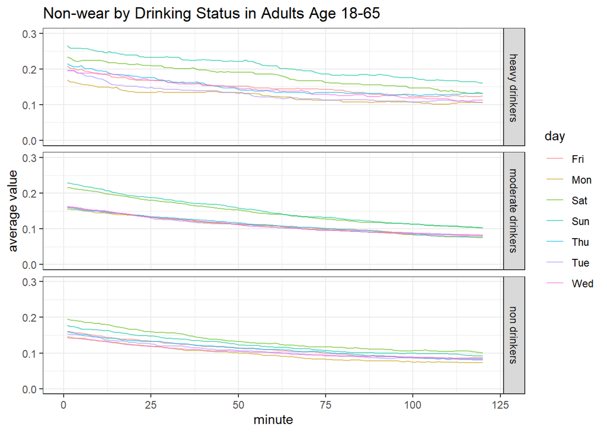

```r
bind_rows(
    mean_column(col_name = "count", data = Flags%>% filter(SEQN %in% intersect(non.drnk, adult) ))%>% mutate(key = "non drinkers"),
     mean_column(col_name = "count", data = Flags%>% filter(SEQN %in% intersect(mod.drnk, adult)))%>% mutate(key = "moderate drinkers"),
    mean_column(col_name = "count", data = Flags%>% filter(SEQN %in% intersect(hv.drnk, adult)))%>% mutate(key = " heavy drinkers")
) %>%
    ggplot(aes(x = minute, y = value, color = day)) +
    xlim(0,120)+
    ylim(0,0.3)+
    geom_line(alpha = 0.6) +
    facet_grid(key ~ ., scales = "free_y") +
    theme_bw() +
    labs(y = "average value", title = "Non-wear by Drinking Status in Adults Age 18-65")
```

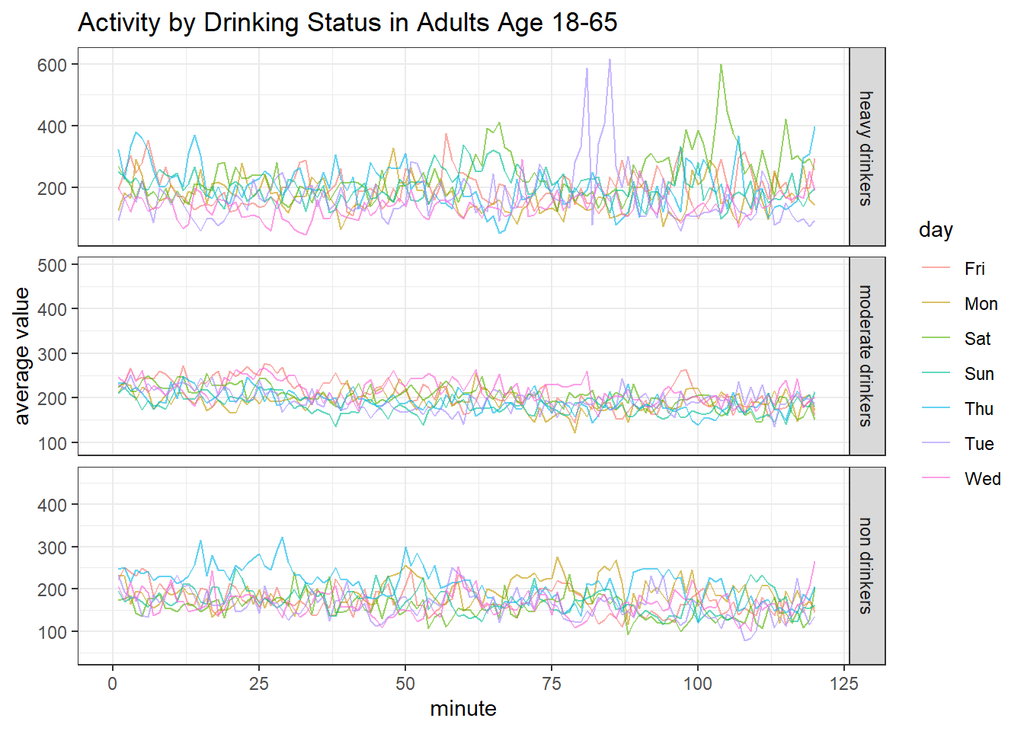

```r
bind_rows(
    mean_column(col_name = "count", data = PAX_clean%>% filter(SEQN %in% intersect(non.drnk, adult) ))%>% mutate(key = "non drinkers"),
     mean_column(col_name = "count", data = PAX_clean%>% filter(SEQN %in% intersect(mod.drnk, adult)))%>% mutate(key = "moderate drinkers"),
    mean_column(col_name = "count", data = PAX_clean%>% filter(SEQN %in% intersect(hv.drnk, adult)))%>% mutate(key = " heavy drinkers")
) %>%
    ggplot(aes(x = minute, y = value, color = day)) +
    xlim(0,120)+
    geom_line(alpha = 0.6) +
    facet_grid(key ~ ., scales = "free_y") +
    theme_bw() +
    labs(y = "average value", title = "Activity by Drinking Status in Adults Age 18-65")
```

```r
# average wear vs non-wear value among heavy-, moderate- and non-drinkers in first 3 hours
hd = Flags %>%
  filter(SEQN %in% hv.drnk)%>%
  select(starts_with("MIN")[1:180]) %>%
  colMeans(na.rm = T)

nd = Flags %>%
  filter(SEQN %in% non.drnk)%>%
  select(starts_with("MIN")[1:180])%>%
  colMeans(na.rm = T)

md = Flags %>%
  filter(SEQN %in% mod.drnk)%>%
  select(starts_with("MIN")[1:180])%>%
  colMeans(na.rm = T)

#test if group averages are different (each data point is an average per that minute)

wilcox.test(hd,md, conf.int = T)
```

```
##
##  Wilcoxon rank sum test with continuity correction
##
## data:  hd and md
## W = 25893, p-value < 2.2e-16
## alternative hypothesis: true location shift is not equal to 0
## 95 percent confidence interval:
##  0.02843812 0.03802337
## sample estimates:
## difference in location
##             0.03285729
```

```r
wilcox.test(hd,nd, conf.int = T)
```

```
##
##  Wilcoxon rank sum test with continuity correction
##
## data:  hd and nd
## W = 28328, p-value < 2.2e-16
## alternative hypothesis: true location shift is not equal to 0
## 95 percent confidence interval:
##  0.03211540 0.04168679
## sample estimates:
## difference in location
##             0.03685269
```

```r
wilcox.test(md,nd, conf.int = T)
```

```
##
##  Wilcoxon rank sum test with continuity correction
##
## data:  md and nd
## W = 17506, p-value = 0.1861
## alternative hypothesis: true location shift is not equal to 0
## 95 percent confidence interval:
##  -0.001085467  0.007266352
## sample estimates:
## difference in location
##            0.002539585
```

```r
## same for activity count

hd_a = PAX_clean %>%
  filter(SEQN %in% hv.drnk)%>%
  select(starts_with("MIN")[1:180]) %>%
  colMeans(na.rm = T)

nd_a = PAX_clean %>%
  filter(SEQN %in% non.drnk)%>%
  select(starts_with("MIN")[1:180])%>%
  colMeans(na.rm = T)

md_a = PAX_clean %>%
  filter(SEQN %in% mod.drnk)%>%
  select(starts_with("MIN")[1:180])%>%
  colMeans(na.rm = T)


wilcox.test(hd_a,md_a, conf.int = T)
```

```
##
##  Wilcoxon rank sum test with continuity correction
##
## data:  hd_a and md_a
## W = 17391, p-value = 0.2279
## alternative hypothesis: true location shift is not equal to 0
## 95 percent confidence interval:
##  -1.476402  6.675371
## sample estimates:
## difference in location
##               2.539917
```

```r
wilcox.test(hd_a,nd_a, conf.int = T)
```

```
##
##  Wilcoxon rank sum test with continuity correction
##
## data:  hd_a and nd_a
## W = 30722, p-value < 2.2e-16
## alternative hypothesis: true location shift is not equal to 0
## 95 percent confidence interval:
##  39.12679 47.08048
## sample estimates:
## difference in location
##               43.16213
```

```r
wilcox.test(md_a,nd_a, conf.int = T)
```

```
##
##  Wilcoxon rank sum test with continuity correction
##
## data:  md_a and nd_a
## W = 31082, p-value < 2.2e-16
## alternative hypothesis: true location shift is not equal to 0
## 95 percent confidence interval:
##  36.50829 44.04781
## sample estimates:
## difference in location
##               40.29363
```

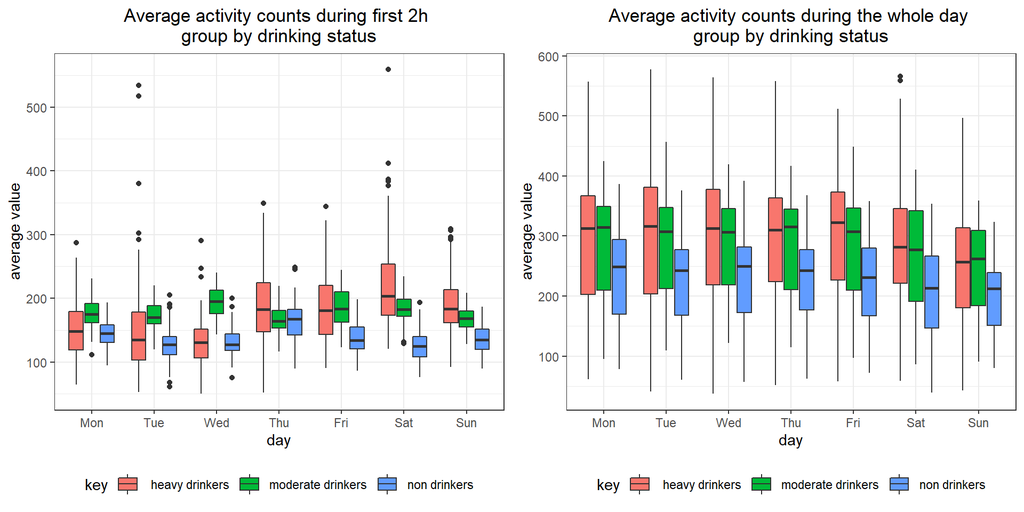

```r
# PA
drnk.data = bind_rows(
  mean_column(col_name = "count", data = PAX_clean%>% filter(SEQN %in% non.drnk))%>% mutate(key = "non drinkers"),
  mean_column(col_name = "count", data = PAX_clean%>% filter(SEQN %in% mod.drnk))%>% mutate(key = "moderate drinkers"),
  mean_column(col_name = "count", data = PAX_clean%>% filter(SEQN %in% hv.drnk))%>% mutate(key = " heavy drinkers")
)
drnk.data$day = factor(drnk.data$day,levels = c("Mon","Tue","Wed","Thu","Fri","Sat","Sun"))
p1 = drnk.data %>%
  filter(minute<=120) %>%
  ggplot(aes(x = day, y = value)) +
  geom_boxplot(aes(fill = key))+
  theme_bw()+
  labs(y = 'average value', title= "Average activity counts during first 2h \ngroup by drinking status")+
  theme(legend.position = "bottom",
        plot.title = element_text(hjust = 0.5))

p2 = drnk.data %>%
  filter(minute<=1440) %>%
  ggplot(aes(x = day, y = value)) +
  geom_boxplot(aes(fill = key))+
  theme_bw()+
  labs(y = 'average value', title= "Average activity counts during the whole day \ngroup by drinking status")+
  theme(legend.position = "bottom",
        plot.title = element_text(hjust = 0.5))
grid.arrange(p1,p2,nrow = 1)
```

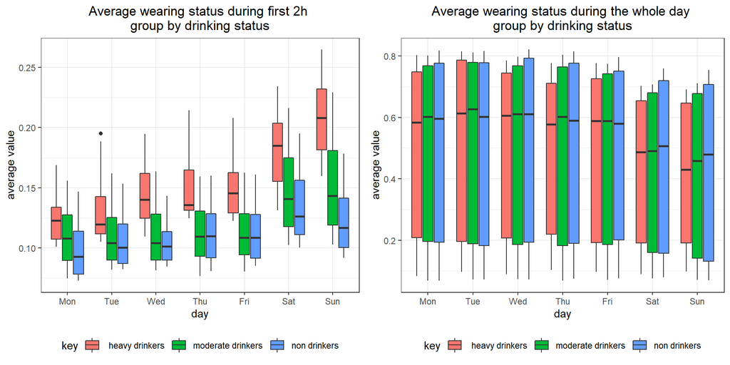

```r
# Wearing
drnk.wear.data = bind_rows(
  mean_column(col_name = "count", data = Flags%>% filter(SEQN %in% intersect(non.drnk, adult) ))%>% mutate(key = "non drinkers"),
  mean_column(col_name = "count", data = Flags%>% filter(SEQN %in% intersect(mod.drnk, adult)))%>% mutate(key = "moderate drinkers"),
  mean_column(col_name = "count", data = Flags%>% filter(SEQN %in% intersect(hv.drnk, adult)))%>% mutate(key = " heavy drinkers")
)

drnk.wear.data$day = factor(drnk.wear.data$day,levels = c("Mon","Tue","Wed","Thu","Fri","Sat","Sun"))

p3 = drnk.wear.data %>%
  filter(minute<=120) %>%
  ggplot(aes(x = day, y = value)) +
  geom_boxplot(aes(fill = key))+
  theme_bw()+
  labs(y = 'average value', title= "Average wearing status during first 2h \ngroup by drinking status")+
  theme(legend.position = "bottom",
        plot.title = element_text(hjust = 0.5))

p4 = drnk.wear.data %>%
  filter(minute<=1440) %>%
  ggplot(aes(x = day, y = value)) +
  geom_boxplot(aes(fill = key))+
  theme_bw()+
  labs(y = 'average value', title= "Average wearing status during the whole day \ngroup by drinking status")+
  theme(legend.position = "bottom",
        plot.title = element_text(hjust = 0.5))
grid.arrange(p3,p4,nrow=1)
```

The most interesting plot will be the one on the lower left corner. There is a tendency of lower average wearing frequency during the first 2 hours of a day from heavy drinkers to moderate drinkers to non drinkers.

This result is interesting since on the lower right corner the heavy drinkers do not wear the device more than people in other groups on a whole day. A possible reason is that the drinkers will tend to stay up late and keep wearing the device before they get to bed.

### Scalar-on-Function Regression Model

Let $Y_i$ be the binary response that patient $i$ is a heavy drinker. ($Y_i= 0$ for both moderate and non-drinkers). We will fit a functional genaralized linear model (FGLM) as follows.

$$logit(p(Y_i=1)) = X_i^{\top} \beta + \int_T f_1(t) Z_i(t) dt + I(Day_i \in Weekend) \int_T f_2(t) Z_i(t) dt$$

```r
rm(list=ls())

## Load data pre-processed in the rnhanesdata package
## Note the naming convention _* denotes NHANES wave.
##      _C = 2003-2004
##      _D = 2005-2006
data("PAXINTEN_C");data("PAXINTEN_D")    ## activity count data matrices
data("Flags_C");data("Flags_D")          ## wear/non-wear flag data matrices
data("Covariate_C");data("Covariate_D")  ## demographic/comorbidity data matrices


###########################################################################
##                                                                       ##
##  Prep accelerometry data for analysis and merge all data  ##
##                                                                       ##
###########################################################################

## Re-code activity counts which are considered "non-wear" to be 0.
## This doesn't impact much data, most estimated non-wear times correspond to 0 counts anyway
PAXINTEN_C[,paste0("MIN",1:1440)] <- PAXINTEN_C[,paste0("MIN",1:1440)]*Flags_C[,paste0("MIN",1:1440)]
PAXINTEN_D[,paste0("MIN",1:1440)] <- PAXINTEN_D[,paste0("MIN",1:1440)]*Flags_D[,paste0("MIN",1:1440)]


## Merge accelerometry (activity counts + wear/non-wear flags) and covariate data.
## We will drop the flag information shortly, but we first use it to identify "good" days of data based on
## estimated wear time
data_C <-
  PAXINTEN_C %>%
  ## note that both PAXINTEN_* and Covariate_* have a column
  ## called "SDDSRVYR" indicating which NHANES wave the data is associated with.
  left_join(Covariate_C, by=c("SEQN","SDDSRVYR")) %>%
  ## Similarly, the activity count (PAXINTEN_*) and wear/non-wear flag matrices (Flags_*) share
  ## SEQN, PAXCAL, PAXSTAT, WEEKDAY, SDDSRVR variables.
  ## In addition, when we join activity and flag data we have duplicated column names.
  ## Supply meaningful suffixes so we can differentiate them
  left_join(Flags_C, by=c("SEQN","PAXCAL","PAXSTAT","WEEKDAY","SDDSRVYR"), suffix=c(".AC",".Flag"))
data_D <-
  PAXINTEN_D %>%
  left_join(Covariate_D, by=c("SEQN","SDDSRVYR")) %>%
  left_join(Flags_D, by=c("SEQN","PAXCAL","PAXSTAT","WEEKDAY","SDDSRVYR"), suffix=c(".AC",".Flag"))

## Combine 2003-2004 and 2005-2006 data into a single data frame
data <- bind_rows(data_C, data_D)

## Estimate total daily wear time and determine whether a day is "good" based on
## >= 10 hours (600 minutes) of wear time + device calibration/quality flags.
## Calculate number of good days per participant (this will be used as an exclusion criteria later -- the standard is >= 3 days),
data <-
  data %>%
  mutate("wear_time" = rowSums(select(., one_of(paste0("MIN",1:1440,".Flag"))), na.rm=TRUE),
         "good_day"  = as.numeric(wear_time >= 600),
         "good_day"  = good_day * (PAXCAL %in% 1) * (PAXSTAT %in% 1),
         "Age" = RIDAGEEX/12,
         "Weekend" = as.numeric(WEEKDAY %in% c(1,7)),
         "heavy_drinker" = as.numeric(DrinkStatus == "Heavy Drinker")
  ) %>%
  group_by(SEQN) %>%
  ## sum up the number of good days
  ## and caluclate a lagged "good" day (i.e. did they wear the device the preceeding day)
  mutate("n_good_days" = sum(good_day),
         "good_day_lag" = c(NA,good_day[-n()])) %>%
  ungroup() %>%
  ## only consider "good" days and subjects with at least 3 days of good data who were
  ## > 21 years old at the interview and < 65 when they wore the accelerometer
  ## and are not missing alcohol consumption data or other predictors of interest
  filter(good_day==1 & n_good_days > 3 & RIDAGEYR >= 21 & Age <= 65 &
           !is.na(DrinkStatus) & !is.na(SmokeCigs) & !is.na(BMI) & !is.na(Gender))

## clean up the workspace (free up RAM)
rm(list=c("data_C","data_D",
          "PAXINTEN_C","PAXINTEN_D",
          "Flags_C","Flags_D",
          "Covariate_C","Covariate_D"))


N       <- nrow(data)        # number of subject-days in the data
col_inx <- 1:120             # minutes of interest: first two hour: 1~120
nt      <- length(col_inx)   # number of mintues total in the model

## The logic for the pfr fit
## recall the basic flr is
## g(E[Y]) = \beta_0 + \int f(t)Z(t)dt
##         ~= \beta_0 + \sum_l \delta_l  f(l) Z(l)     - numeric integration
##         =  \beta_0 + \sum_l [\delta_l Z(l)] f(l)
## Which we can model using gam via a linear functional term (see ?linear.functional.terms)
## by creating a matrix corresponding the the elementwise product of a numeric integration matrix
## by the functional predictor


## store functional predictor data as a matrix within the data frame
## use the wear/non-wear flags instead of the activity counts
#data$X <- I(log(1+as.matrix(select(data, paste0("MIN",col_inx,".AC")))))
data$X <- I(as.matrix(select(data, paste0("MIN",col_inx,".Flag"))))
## matrix of time indices
tind      <- seq(0,1,len=nt)
data$tmat <- I(matrix(tind, ncol=nt, nrow=N,byrow=TRUE))
## Riemann integration matrix
data$lmat <- I(matrix(1/nt,ncol=nt, nrow=N))
## matrix of weekend indicators
data$wknd <- I(matrix(rep(data$Weekend, each=nt), ncol=nt, nrow=N))
## integration matrix multiplied by the functional predictor
data$L.X  <- I(data$X*data$lmat)
## integration matrix multiplied by the functional predictor by the weekend indicator
data$LW.X <- I(data$X*data$lmat*data$wknd)

## fith with no wearing status predictors
fit_none <- gam(heavy_drinker ~ Age + SmokeCigs + BMI + Gender, data=data, family=quasibinomial())
## model fit ignoring weekend vs weekday
## note that I'm using cyclic splines because I'm considering the whole day! If you're only considering a subset of
## the day you may want to change bs="cc" to bs="cr"
fit_gam <- gam(heavy_drinker ~ Age + SmokeCigs + BMI + Gender +  s(tmat, by=L.X, bs="cr",k=15), data=data, family=quasibinomial(),method="REML")
# fit_pfr <- pfr(heavy_drinker ~ Age +  lf(X, bs="cc",k=15, integration="riemann"), data=data, family=quasibinomial(),method="REML")
## identical fits!

## model fit allowing for affect to differ by PA on weekend
fit_gam_wknd <- gam(heavy_drinker ~ Age + SmokeCigs + BMI + Gender +
                      s(tmat, by=L.X, bs="cr",k=15) +
                      s(tmat, by=LW.X, bs="cr",k=15), data=data, family=quasibinomial(),method="REML")

## plot the fits
#par(mfrow=c(2,2))
#plot(fit_gam); plot.new()
#plot(fit_gam_wknd)

## get individual estimated probabilities
data$phat_day_none     <- predict(fit_none, newdata=data, type='response')
data$phat_day      <- predict(fit_gam, newdata=data, type='response')
data$phat_day_wknd <- predict(fit_gam_wknd, newdata=data, type='response')
## average across days
data_ind <-
  data %>%
  select(SEQN, heavy_drinker, phat_day_none, phat_day, phat_day_wknd) %>%
  group_by(SEQN) %>%
  dplyr::mutate(phat_ind_none = mean(phat_day_none),
                phat_ind = mean(phat_day),
                phat_ind_wknd = mean(phat_day_wknd)) %>%
  slice(1) %>%
  ungroup() %>%
  select(-phat_day_none, -phat_day, -phat_day_wknd)

## calculate AUC using the pROC package
library(pROC)
roc(data_ind$heavy_drinker, data_ind$phat_ind_none)
```

```
##
## Call:
## roc.default(response = data_ind$heavy_drinker, predictor = data_ind$phat_ind_none)
##
## Data: data_ind$phat_ind_none in 3758 controls (data_ind$heavy_drinker 0) < 304 cases (data_ind$heavy_drinker 1).
## Area under the curve: 0.7374
```

```r
roc(data_ind$heavy_drinker, data_ind$phat_ind)
```

```
##
## Call:
## roc.default(response = data_ind$heavy_drinker, predictor = data_ind$phat_ind)
##
## Data: data_ind$phat_ind in 3758 controls (data_ind$heavy_drinker 0) < 304 cases (data_ind$heavy_drinker 1).
## Area under the curve: 0.7385
```

```r
roc(data_ind$heavy_drinker, data_ind$phat_ind_wknd)
```

```
##
## Call:
## roc.default(response = data_ind$heavy_drinker, predictor = data_ind$phat_ind_wknd)
##
## Data: data_ind$phat_ind_wknd in 3758 controls (data_ind$heavy_drinker 0) < 304 cases (data_ind$heavy_drinker 1).
## Area under the curve: 0.7426
```

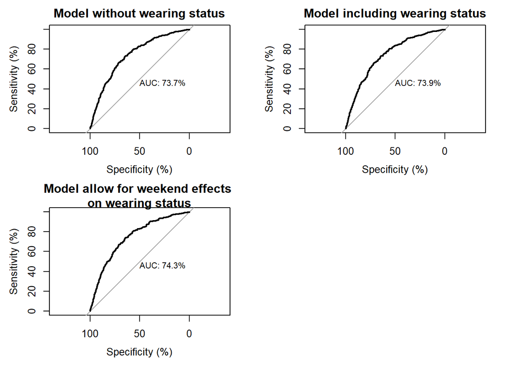

```r
par(mfrow=c(2,2))

plot.roc(data_ind$heavy_drinker, data_ind$phat_ind_none,
         percent = TRUE,
         print.auc=TRUE,
         main = "Model without wearing status")

plot.roc(data_ind$heavy_drinker, data_ind$phat_ind,
         percent = TRUE,
         print.auc=TRUE,
         main = "Model including wearing status")

plot.roc(data_ind$heavy_drinker, data_ind$phat_ind_wknd,
         percent = TRUE,
         print.auc=TRUE,
         main = "Model allow for weekend effects \non wearing status")
```

The most flexible model has slightly higher AUC, which is good.

We create histograms by `ggplot2` to evaluate the performance of fitting:

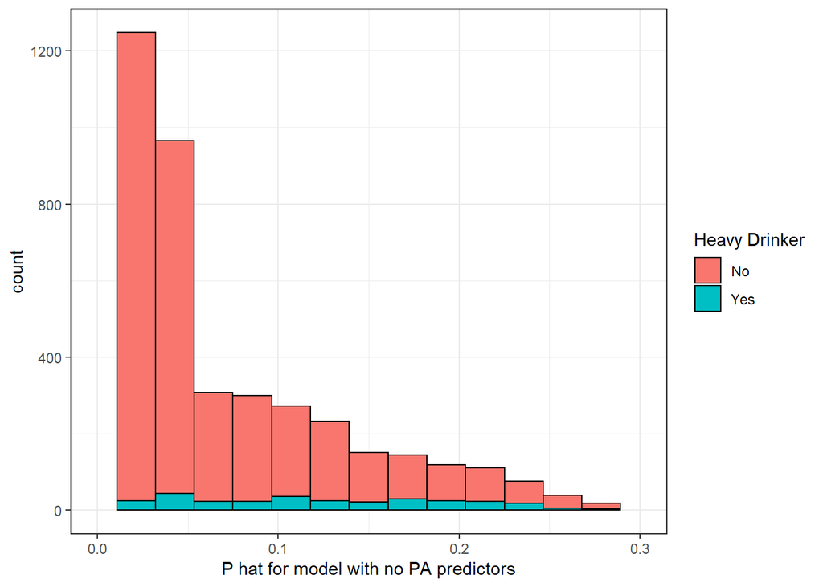

```r
plot1 <- ggplot(data = data_ind, aes(x = phat_ind_none, fill = as.factor(heavy_drinker))) +
  geom_histogram(color = "black", bins = 15) +
  xlim(c(0, 0.3)) +
  theme_bw() +
  scale_fill_discrete(name = "Heavy Drinker", breaks = c("0", "1"), labels = c("No", "Yes")) +
  labs(x = "P hat for model with no PA predictors")

suppressWarnings(print(plot1))
```

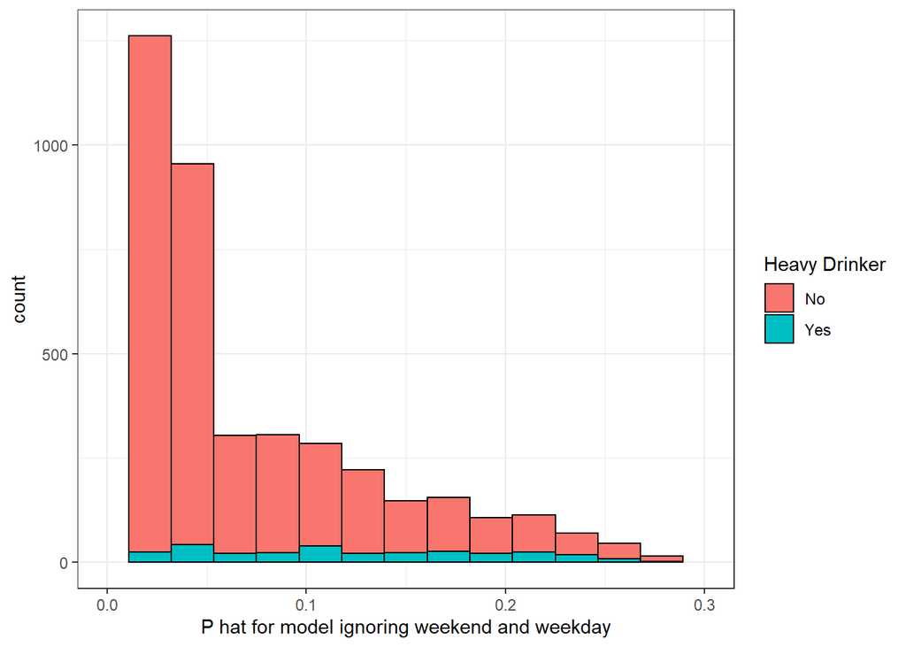

```r
plot2 <- ggplot(data = data_ind, aes(x = phat_ind, fill = as.factor(heavy_drinker))) +
  geom_histogram(color = "black", bins = 15) +
  xlim(c(0,0.3)) +
  theme_bw() +
  scale_fill_discrete(name = "Heavy Drinker", breaks = c("0", "1"), labels = c("No", "Yes")) +
  labs(x = "P hat for model ignoring weekend and weekday")

suppressWarnings(print(plot2))
```

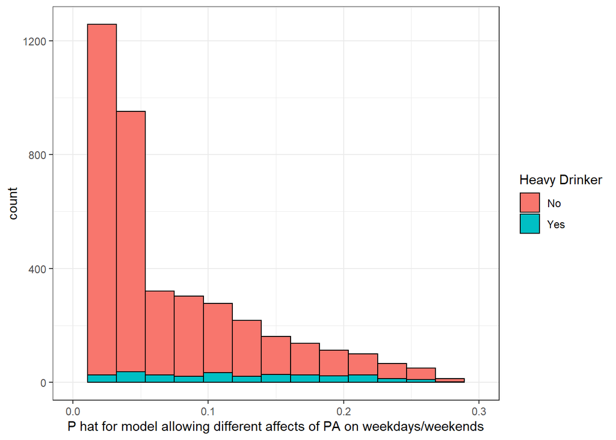

```r
plot3 <- ggplot(data = data_ind, aes(x = phat_ind_wknd, fill = as.factor(heavy_drinker))) +
  geom_histogram(color = "black", bins = 15) +
  xlim(c(0, 0.3)) +
  theme_bw() +
  scale_fill_discrete(name = "Heavy Drinker", breaks = c("0", "1"), labels = c("No", "Yes")) +
  labs(x = "P hat for model allowing different affects of PA on weekdays/weekends")

suppressWarnings(print(plot3))
```

For these models, the blue parts (indicating heavy drinkers) will hold a larger proportion for a given $\hat{p}$ when that $\hat{p}$ is larger.

These plots also indicate that the three models do make some sense on distinguishing heavy drinkers from non-heavy drinkers.